# Lab 02 - Plastic waste

Jonathan Trattner

Last compiled on February 04, 2021

## Load packages and data

```r
library(tidyverse)
```

```r
plastic_waste <- read_csv("data/plastic-waste.csv")
```

## Exercises

### Exercise 1

The distributions are right-skewed! Maybe it looks like a $\gamma$ distribution.

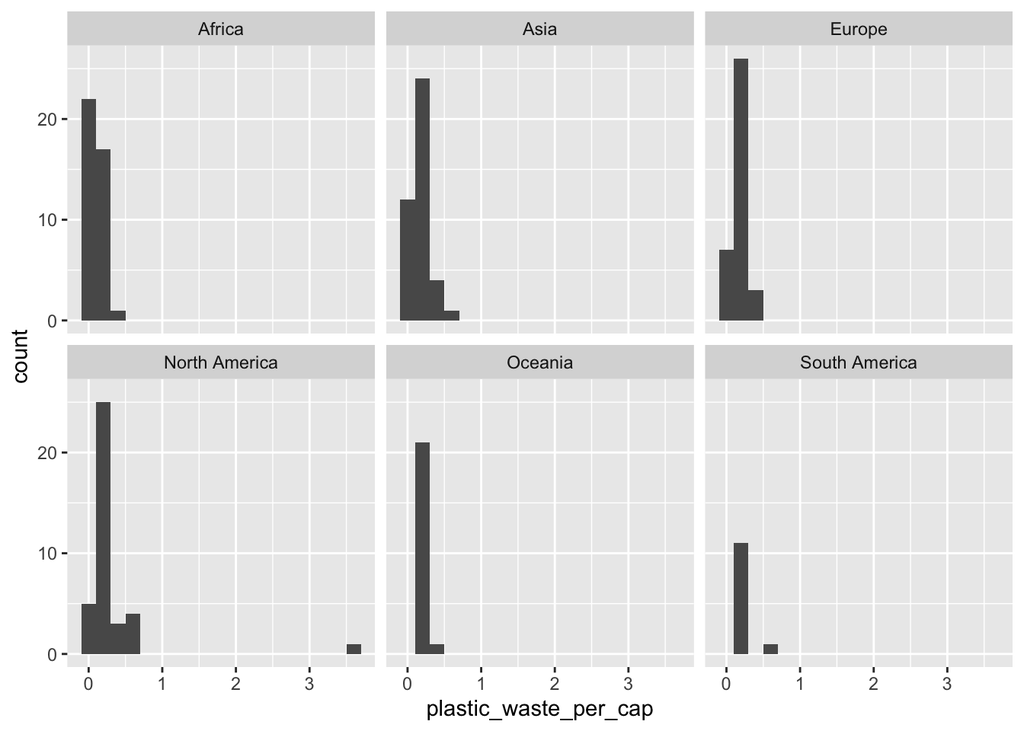

```r
ggplot(plastic_waste, aes(x = plastic_waste_per_cap)) +
  geom_histogram(binwidth = 0.2) +
  facet_wrap(~continent)
```

### Exercise 2

Yep, definitely looks like a $\gamma$ distribution.

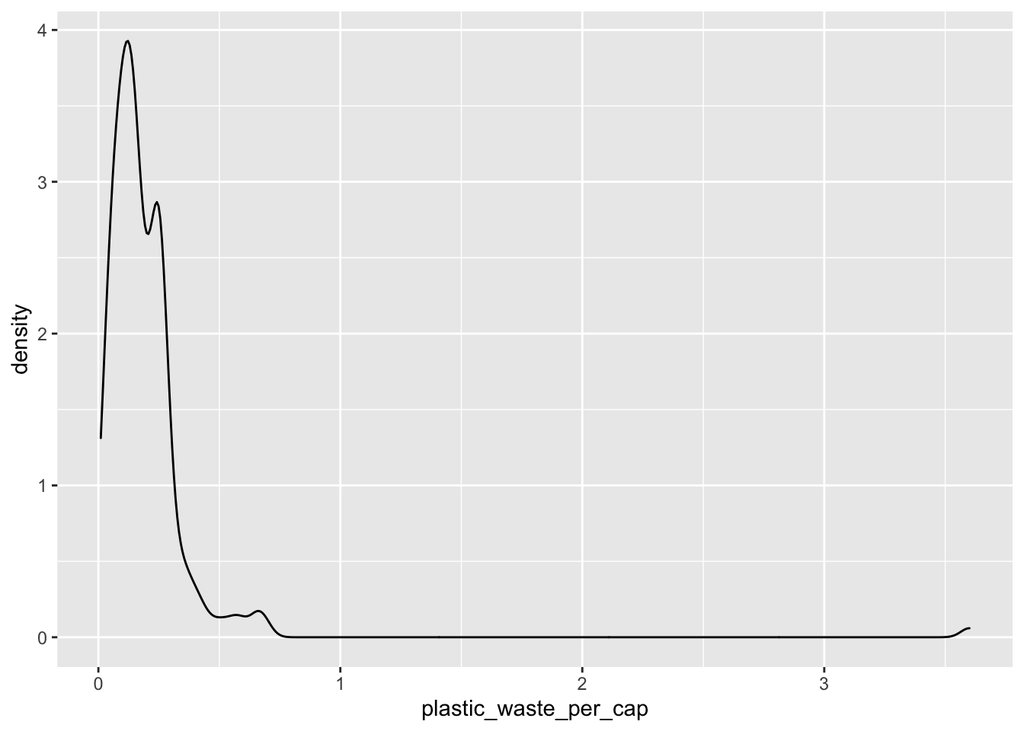

```r
ggplot(data = plastic_waste, aes(x = plastic_waste_per_cap)) +
  geom_density()
```

### Exercise 3

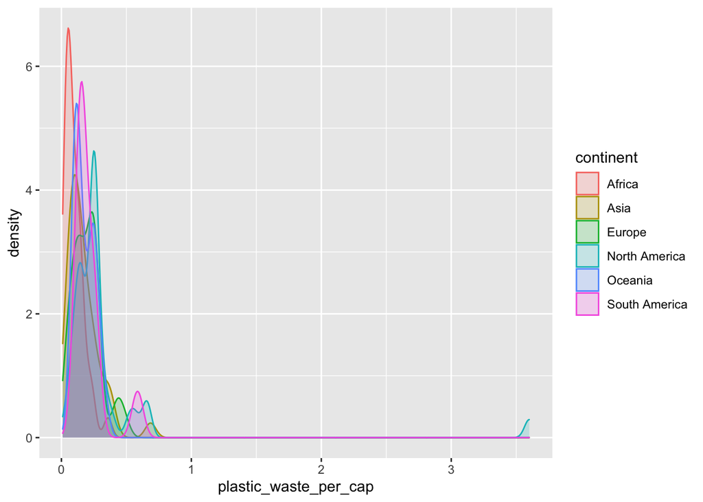

```r
ggplot(data = plastic_waste,
       mapping = aes(x = plastic_waste_per_cap,
                     color = continent,
                     fill = continent)) +
  geom_density(alpha = 0.2)
```

We defined the color and fill of the curves by mapping the aesthetics of the plot because those are dependent upon the continent variable. We defined the alpha outside of that because that is independent of any variables. That is, we map aesthetics to variables but not things independent of them.

### Exercise 4

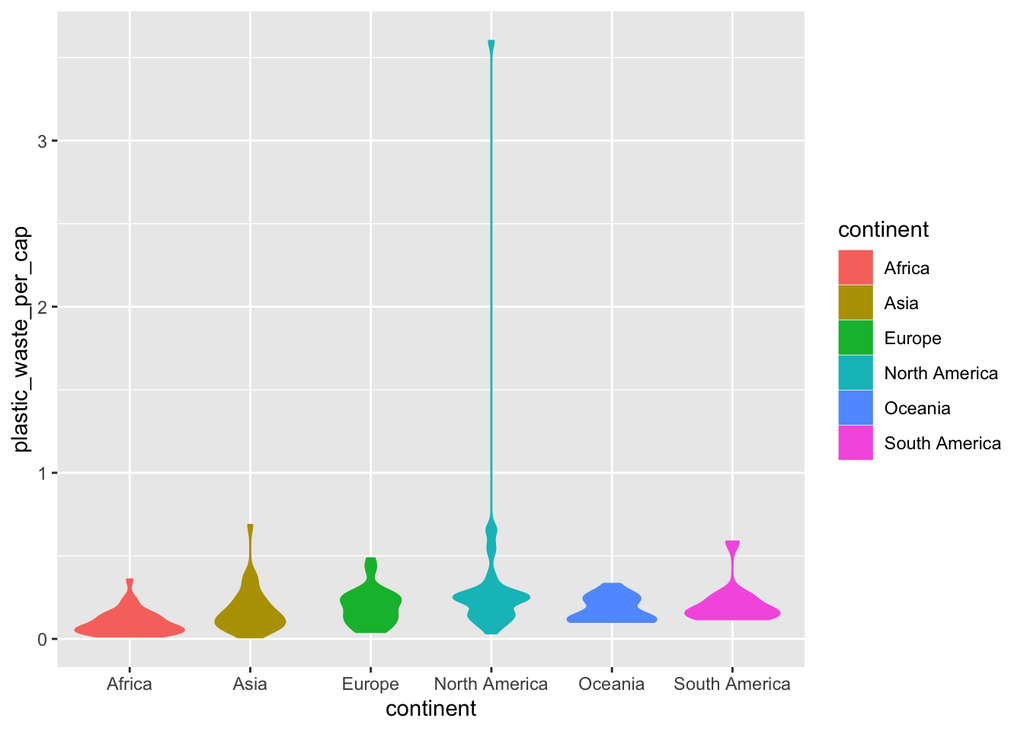

```r
ggplot(data = plastic_waste,
       mapping = aes(x = continent,
                     y = plastic_waste_per_cap,
                     color = continent,
                     fill = continent)) +
  geom_violin()
```

The violin plot reveals the relative distribution of each variable (i.e. the density within groupings). It is, according to the docs, a combination of `geom_density()` and `geom_boxplot()`.

### Exercise 5

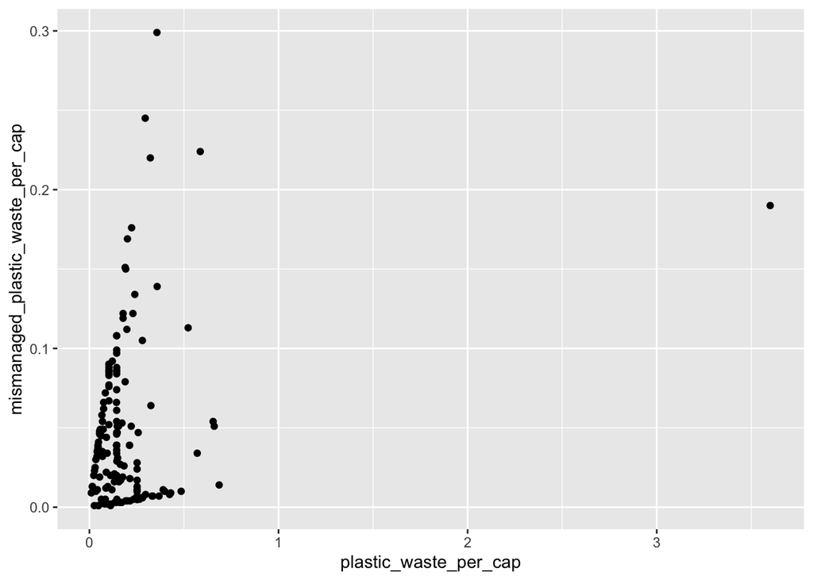

```r
ggplot(data = plastic_waste,
       mapping = aes(x = plastic_waste_per_cap,
                     y = mismanaged_plastic_waste_per_cap)) +
  geom_point()
```

There seems to be a positive relationship between mismanaged plastic waste per cap and plastic waste per cap (perhaps unsurprisingly).

### Exercise 6

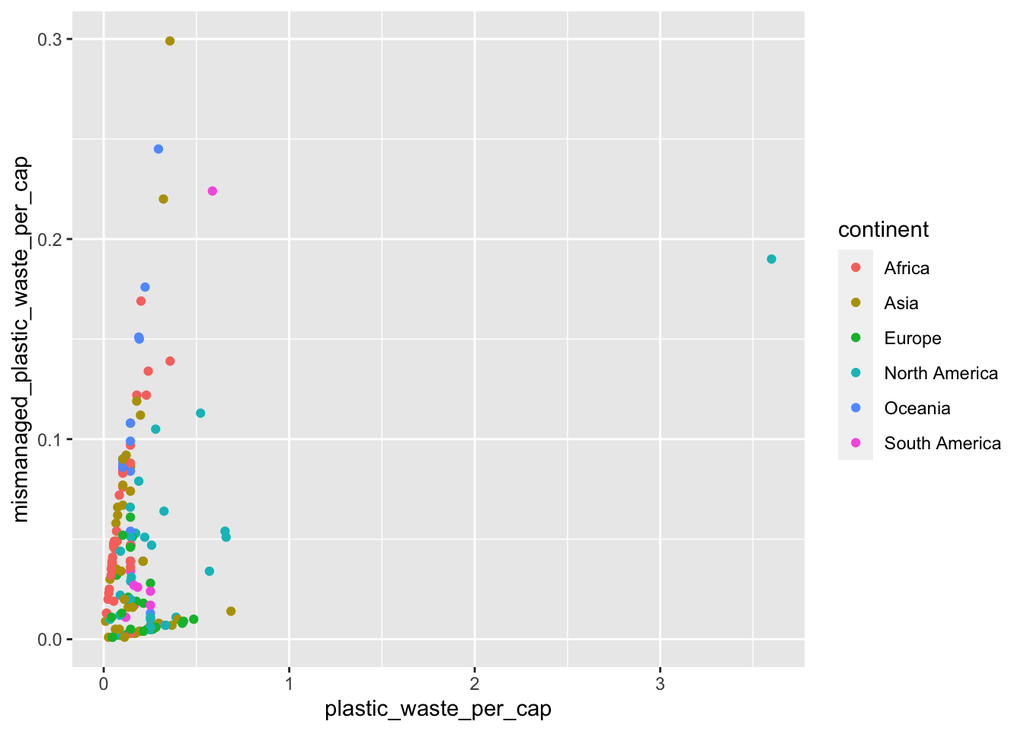

```r
ggplot(data = plastic_waste,
       mapping = aes(x = plastic_waste_per_cap,
                     y = mismanaged_plastic_waste_per_cap,
                     color = continent)) +
  geom_point()
```

There don’t seem to be any *clear* distinctions between continents and plastic waste (mismanagement) per capita. Though *maybe* Asia and Africa look like they have a higher slope…?

### Exercise 7

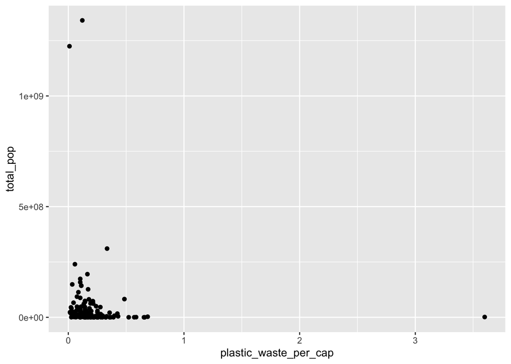

```r
ggplot(data = plastic_waste,
       mapping = aes(x = plastic_waste_per_cap,
                     y = total_pop)) +
  geom_point()
```

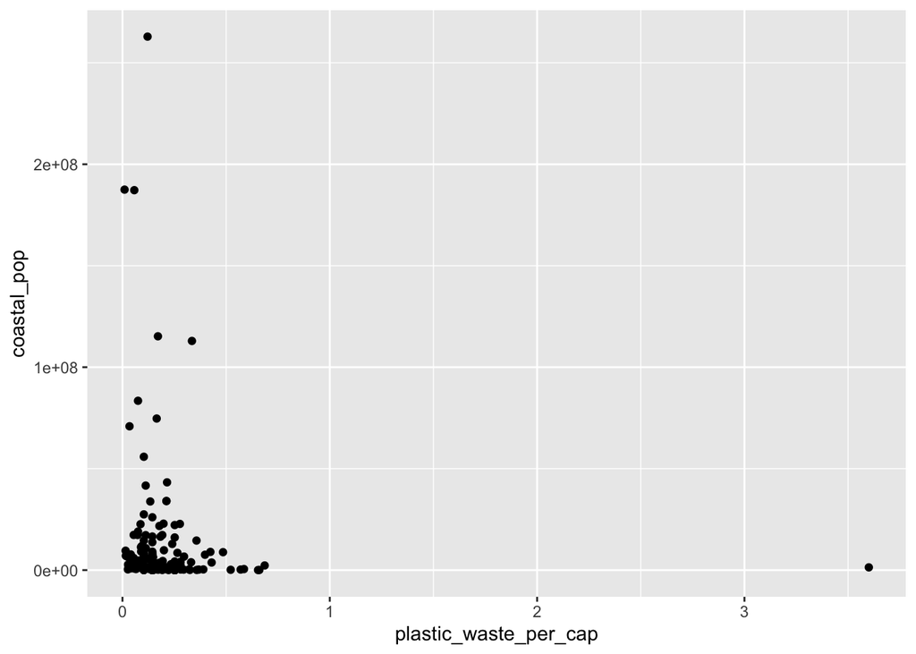

```r
ggplot(data = plastic_waste,
       mapping = aes(x = plastic_waste_per_cap,
                     y = coastal_pop)) +
  geom_point()
```

Neither of these plots seem to have a stronger linear relationship than the one seen in exercise 6

### Exercise 8

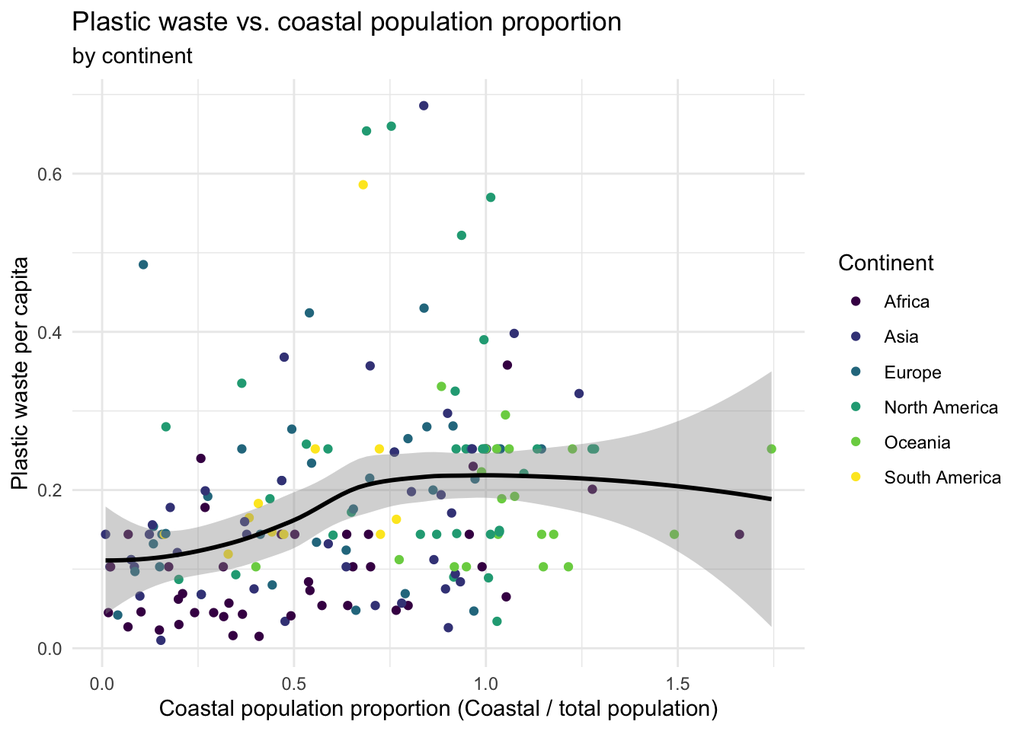

```r
plastic_waste %>%
  mutate(coast_prop = coastal_pop / total_pop) %>%
  filter(plastic_waste_per_cap < 3) %>%
  ggplot(aes(x = coast_prop,
             y = plastic_waste_per_cap)) +
  geom_point(aes(color = continent)) +
  geom_smooth(color = "black") +
  scale_color_viridis_d() +
  theme_minimal() +
  labs(title = "Plastic waste vs. coastal population proportion",
       subtitle = "by continent",
       color = "Continent",
       x = "Coastal population proportion (Coastal / total population)",
       y = "Plastic waste per capita")
```